# fwdPathPaper

skyebend

December 11, 2015

# Potential Applications of Earliest Arriving Forward Paths for Evaluating Transmission Potential in Dynamic Networks

## Transmission in networks background

Reasearchers in a wide range of fields have studied transmission processes in networks for several decades. Key contributions have been published addressing problems in transit logistics, network routing, livestock disease transmission, diffusion of innovations, percolation networks, “viral” social media, and epidemiology.

Characterising static networks with useful descriptive statistics is quite challenging, and adding a temporal dimension greatly increases the complexity of the problem. Relatively few generalizeable descriptive statistics for dynamic networks have been published. Those that exist frequently operate by dividing the longitudinal network up into a series time bins, aggregating ties within those bins into static networks, and calculating a network statistic on each bin. This often a useful approach, and one that can return graph statistics as a time series (cite papers, tsna), but number of issues arise. Determining an appropriate bin duration can be difficult. Although the density-inflating effects of short-duration aggregations may not be as sever as aggregating over the entire observation period, it still will collapse tie sequence effects and add a bias to the network measures.

The goal of this paper is to outline and demonstrate several algorithmic approaches to characterising the transmission potential in longitudinal networks by computing sets possible temporally permissable traversals of the network. There is a growing literature which uses simulated epidemics across longitudinal networks. Epidemic models require specifying their own set of parameters and the specific details of individual transmission processes may vary widly across phenomena, perhaps depending on quantities that are difficult or unethical (in some epidemiology cases) to measure directly. Our hypothesis is that computing properties of the of “substrate” of dynamic network ties which facilitate and bound potential transmission will allow inferences about the size and speed of potential epidemic spread.

## Definitions of dynamic networks and temporal paths

We are considering here a class networks where the existance of edges are presumed to constrain possible transmissions between vertices. The assumption is that the network has either been fully observed (simulated, pre-scheduled) before the transmission process takes place, or the transmission process is independent of the edge dynamics (unable to influence formation or dissolution of ties). So we might include the network fromed by the routing of cargo through an previously scheduled transit network, but not a network of phone calls where people may decide whom to call based on the information they recieve in a previous call.

For the purposes of this paper we consider a dynamic network to be a collection of vertices and incident undirected edges (or directed arcs) in which each element has an associated set of *activity spells* that determine when the elements are availible for transmission. An activity spell has *onset* and *terminus* time values defining a right-open interval. Each element may have multiple spells associated with it (meaning that an edge may toggle on and off multiple times) but the spells must be non-overlaping. A dynamic network also has a (sometimes implicit) *observation window* defining the interval of time (generally inclusive of all the finite edge and vertex spells) over which the network was known to be observed (or simulated).

This definition of dynamic networks is inclusive of (but not restricted to) the common representation of a dynamic network as a sequence of static networks or stack of time-indexed matricies corresponding to sucessive discrete time units or survey waves. For example, the following sequence of adjacency matrices describes a three-vertex directed network observed at three time points.

```
  A B C
A 0 1 0
B 1 0 1
C 0 0 0
```

```
  A B C
A 0 0 0
B 0 0 1
C 1 0 0
```

```
  A B C
A 0 1 0
B 0 0 1
C 0 1 0
```

The same information represented as the activity spell matrices for each edge. Each row is a spell, the first column is the onset, and the second is the terminus.

```r
edgeSpells
```

```
$`edge B-A`
     [,1] [,2]
[1,]    0    1

$`edge A-B`
     [,1] [,2]
[1,]    0    1
[2,]    2    3

$`edge B-C`
     [,1] [,2]
[1,]    0    3

$`edge C-A`
     [,1] [,2]
[1,]    1    2

$`edge C-B`
     [,1] [,2]
[1,]    2    3
```

This distinction in representation is important because the “edge spell” representation permits independently assigning real-valued activity times to each edge and allows us to explicitly consider the order and sequence of edge activations when searching for potential paths.

A *forward temporal path* is a sequence of vertices and edges in a dynamic network such that the start times of successive elements are greater than or equal than those of the previous. The path is a traversal of the network (occuring within its observation window) that respects the constraints of edge activity spells and permits “waiting” at intermediate vertices for edges to form in the future. Due to the required ordering of events, a temporal path is a *directed* traversal, even if the underlying network itself is undirected. Bui Xuan, et al (2002) call a permissable time-respecting path between a pair of vertices (a source and destination) a *journey*.

To give a concrete example, if a network describes the time-evolution of contacts between people during which disease transmission could occur, a sequence of infection events spreading out through network from a single person would be a temporal path. Likewise, a series of time-stamped messages forwarding a cute cat picture would be a temporal path in a dynamic email network. For simplicity we assume that once a path (message) reaches a vertex, that vertex remains “infected” and can transmit to all of its future contacts.

Depending on network topology, there may be zero or arbitrairly many possible temporal paths between a single pair of vertices. Temporal paths are often not symmetric: if vertex `i` can reach vertex `j`, it does not follow that `j` can necessairly reach `i`. This means that a dynamic network can be connected in the static sense (edges exist linking all of the vertices in a single component) but not fully reachable via temporal paths because an edge needed to complete the path becomes inactive before the adjacent edge activates.

Determining if a given path between two vertices is a permissable temporal path or journey requires specifying a starting time point from which the path should be evaluated. This is often, but not always, the beginning of the network observation window. A journey that is possible at at a given time point may not be feasible if it was ininitiated later on. A complete specification of allowable paths also requires being explicit about the duration of time required for a path to cross an edge – further details below.

### Examples of forward temporal paths

Many authors have provided basic examples illustrating the differences betweeen vertices reachable accoring to a static or time-aggregated view of a network in contrast to an allowable temporal path, which we won’t reproduce here. But it is worth working through several path examples in a trivial network. In the network diagram below, the labels on the edges indicate their activity spells.

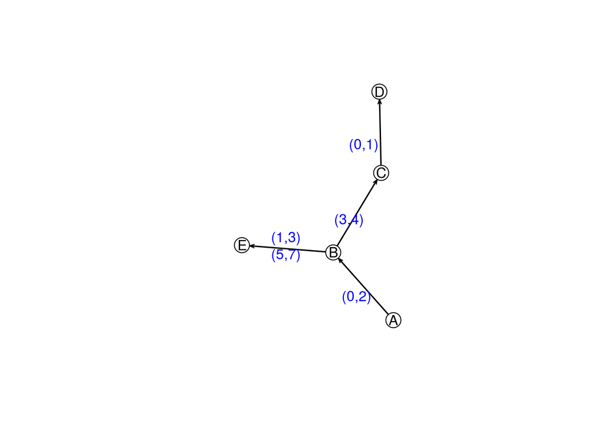

For a network this simple it is possible to tabulate the possible temporal paths paths from vertex A. Of course, vertex B is reachable from A from time 0 until time 2. Vertex C is reachable from A from time 3 until time 4 – allowing for waiting at B for one time unit. Vertex D is never reachable on a temporal path from A, because the C–D edge dissolves before the B–C edge forms. Vertex E is reachable from A from time 1 until 3, and again from time 5 until 7. If we did not allow waiting on vertices, E could only be reached from A from time 1 until 2, and C would not be reachable. Also, if we started our path search from A after time 2 then none of the other vertices are reachable from A.

A common alternate conceptualization of a discrete time temporal network is to consider a *time projected* network (cite moody and earlier) representation. We imagine this as a static network constructed as an ordered sequence of the networks corresponding to each wave, with each vertex connected to its realization in the subsequent time network by a directed *identity arc*. A temporal path in a time projected network can reach forward in time only along the identity arcs and spread across the network via the regular network ties. The image below shows a projection of the seven timesteps of the trivial network and highlights in red some possible forward temporal paths originating from vertex A at the first timestep.

```
## glX
##   1
```

[interactive chart not shown]

This image also illustrates that there are often multiple possible forward temporal paths between pairs of vertices. In the image the link from A to B at time 0 is hilighted, and the second link is not. If this network was representing a continous time process, the journey could also have crossed at time 1.5, or any intermediate time, and this possibility is not well indicated in the representation. For this reason, the time projection representation does not generalize well to continous-time networks where observations have not been made in discrete waves and edges may have varying durations and onset times.

### Various temporal path types

Some existing literature on paths assumes both a discrete time representation of networks, and that the edge between two vertices can only be active for a single discrete time step. Often neglecting to specifiy what the ‘optimal’ path is optimizing. If we allow the edges of dynamic networks to have multiple activiation spells, or to be active for multiple units of time we may also distinguish among various types of possible temporal paths with different restrictions on timing. For example, if we are describing transportation logistics schedules it is possible to use the global overview of the network to plan optimal journeys across the network. What is the quantity that the planner (or algorithm) is attempting to optimise (or minimize)? Are we looking for the earliest possible time we could arrive at a destination? The shortest possible time in transit? The latest possible departure time that still arrives within our bounds? The fewest number “hops” along the route (i.e. least number of plane changes)? When dynamic networks applied for epidemic propagation problems we can generally make an assumption that the element being propagated is passive with respect to its transmission events - it is not able to plan its route. In these cases we are likely interested in the most probable paths. If the underlying network is structured so that alternate routes and / or alternate timing of routes are possible, it is likely that each of these criteria could result in a different path being selected between the same pair of vertices.

To illustrate some of the possible path types, we can define a dynamic network consisting of the following edge spells to contrast five path types.

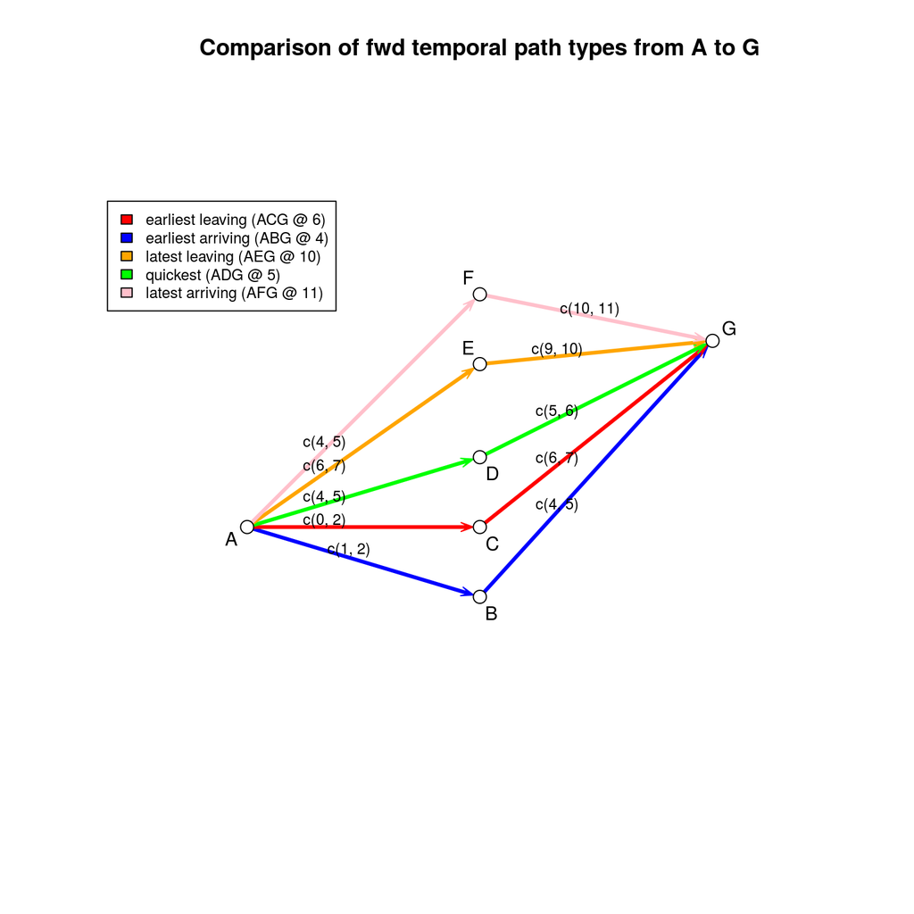

For the examples above, we are only varying the activity timing of the edges, and all of the paths are two geodesic steps in length. This need not be the case for real networks where it is quite possible to have instances where there are shorter (fewer steps) paths that arrive later. It is important not to conflate the earliest path with the shortest path, or even the earliest shortest path.

The example below contrasts multiple-step paths from A to C.

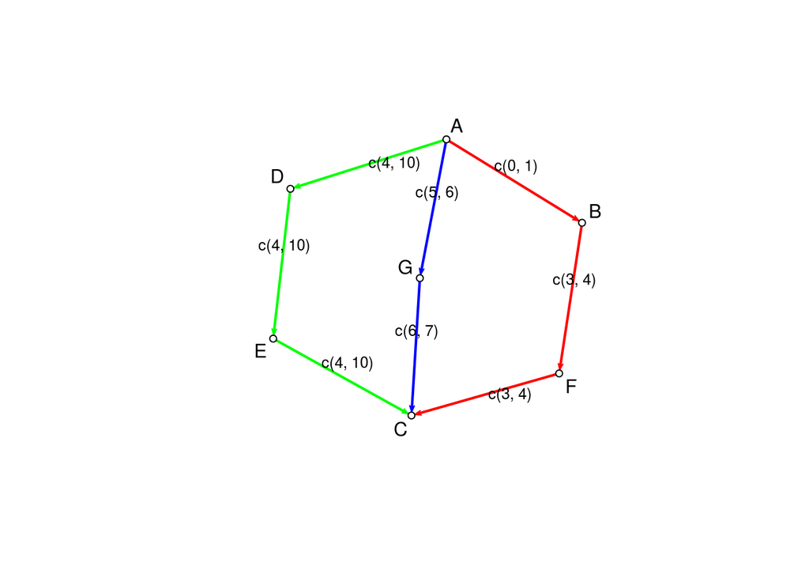

If a network is a spanning tree, and each edge is permitted only a single spell having momentary activiation, all of the deffintions collapse together? Prove?

### Earliest forward path

The earliest arriving forward temporal path from vertex i to vertex j can be thought of as the soonest possible time a message sent from i to j could possibly arrive. Because it depends on the sequence of edge timing, the earliest forward path is not usually equal to the shortest path geodesic in a static network and may not be the same as the shortest temporal path. If an earliest arriving path exists, we know there must be at least one valid forward path, so we can use it to compute temporal reachability. And, as we will see below, we can calculate the earliest path with relative efficiency using algorithms similar to those used to calculate the shortest geodesic path (Bui Xuan, et al. 2002).

The key feature is that much like “shortest geodesic”, “earliest arrival” is quantity that can be minimised with respect the the starting time point of the path. In other words, if we are searching through the network in temporal order and have found an earliest path from i to j at t0, no *earlier* path between them can be created at a later time t > t0. It is crucial to remember that it is often possible to discover *shorter* paths (fewer graph hops) between i and j at later times, it is just that such a path by definition would still occur later.

The earliest arriving forward temporal path is convinient in that it appears to be well-defined for large class of network representations. It can be computed for networks using both discrete and continuous time models, for edges that momentary activation or explicit intervals of duration, and for networks that have either single or multiple edge spell activations betwen a vertex dyads.

## Computing earliest forward paths

The `networkDynamic` package for `R` (Butts, et. al. 2012) provides a realization of the dynamic network data model described above, in which each edge has an associated set of spells defining its activity. This makes it possible to construct an adaptation of the well known Dijkstra shortest path algortihm for weighted networks to compute the earliest forward paths. Essentially the edge weights, and hence the distance to be minimized, are replaced with the amount of time elapsed from the starting point of the path (temporal distance), rather than the number of hops in the graph traversal (path distance).

The for discrete networks, the algorithm can be thought of as computing a shortest path in the ‘time projected’ network (Moody 2008)–except that we are not limited to discrete time and the duration of the ‘self-edges’ need not be uniform.

### Pseudo code for earliest forward path Dijkstra varient

```
# assume 'v' is vertex id of source vertex
# assume that the interval 'start' 'end' defines the observation window to be searched
# define vector of distances to all possible targets, default to un-reachable (Inf)
# define vector used for reconstructing the path, gives the previous (parent) of each vertex
# set temporal distance of 'v' to 0
# define a vector of unchecked vertices

# continue looping while any vertices remain unchecked
   # chose a vertex 'u' to be the unchecked vertex having the smallest temporal distance found so far
   # remove the vertex 'u' from the list of unchecked vertices
   # if the temporal distance associated with 'u' would place it outside the observation window bounds
      # then no more vertices are reachable from 'v' within time range, so end the search
   # check neighbors of 'u' by getting a vector e of connected edges
   # for each edge in 'e in the vector of 'u's edges
      # choose w as id of u's neighbor on the edge
      # find the index of the earliest active spell of the edge 'e' intersecting with 'u's currently computed distances and 'end'
        # (if we are using graph.step.time > 0, may need to search for a later spells here)
        # if no active spells are found
          # vertex 'w' is never reachable in the future / within time bound, so mark its distances as Inf
        # if an active spell is found
          # define distance u_w as the later of 0 or the difference between the
          # currently computed 'u' time and the onset of the spell for edge 'e'
          # (but if we are counting graph steps as part of the distance, distance can't be less than graph step)
      # define dist_v_w as currenctly computed distance for 'u' plus distance u_w
      # if distance_v_w is less than the previously computed distances for 'w'
         # update the distance for 'w' to the new distance
         # update the record for 'w's previous parent to 'u'
# return the vector of distances found and parents of each vertex
# un-reachable vertices will be marked with Inf
```

This algorithm, implemented in the `tPath` function of the `tsna` package (Bender-deMoll and Morris, 2015) has the advantage of being quite fast for temporally sparse networks because it is able to directly access the activiation spells for each edge, and it does not need to ‘visit’ any of the intermediate time points. It can be modified to account for transmssion delays (`graph.step.time`) , and with early termination criteria if the goal is only to find the earliest pair-wise path from i to j (instead of the paths from i to all reachable vertices).

Note that in the case that there are two exactly equvilant earliest arriving forward paths, this algorithm will pick one of the two aribitrairly depending on the specific data structures and details of the implementation. The information on alternate paths is not recorded as it could be in a Breadth First Search algorithm.

Because of the posibility of a shorter (fewer hop) path occuring at a later time, this algorithm cannot be used to find the more general case of a shortest (geodesic) time respecting paths.

This algorithm does not function in the presense of any negatively valued times, so if the starting point for the observation window is earlier than zero, all of the spell values must be shifted by a constant offset to be greater than zero before starting the computation

In the situation where all of the edges have identical activation spells (i.e. edge dynamics could be ignored and represented as static) the algorithm will not directly reduce to a standard shortest path problem because there is no temporal distance between sucessive edges. An effective work around is to define a temporal cost to each edge transmission using `graph.step.time`.

## Transmission trees and forward reachable sets

A *forward reachable set* for `v` at `t` is the complete set of vertices that can be reached along forward temporal paths from a vertex `v` starting at time `t`. There must exist an earliest arriving path if a forward path exists, so we can efficiently compute the forward reachable set using the earliest arriving path.

A forward reachable set can have an associated *tPath*, which is a record of a sequence in which vertices in a forward (or backwards) reachable set are reached along (usually multiple) journeys from a single source vertex, along with the timing of of each graph hop. A tPath defines a temporally permissiable spanning tree for the network, given a seed vertex and start time.

To illustrate the concept of a tPath we will look at some examples of possible paths in a small simulated discrete time network. We can get an idea of the momentary connectivity and spread of the forward paths by looking at a series of snapshots of the network with the vertices that the path from vertex 11 has reached hilighted in red.

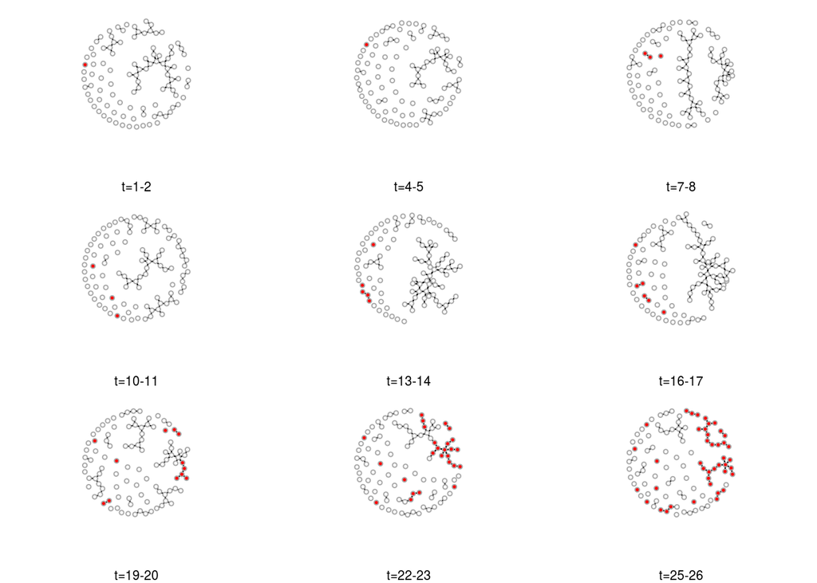

However, this representation doesn’t make the sequence and spread of the path clear. To get a clearer sense of the generations, we can show the path alone as a tree.

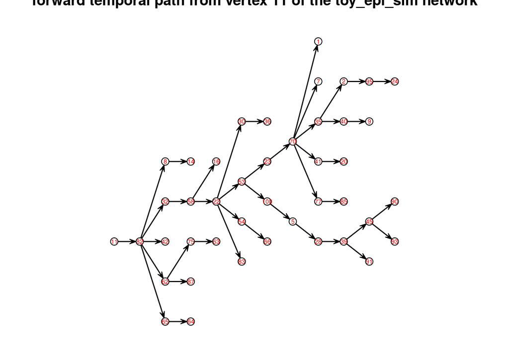

This however, mostly discards the timing information – we know the sequence, but we can’t see when the vertices were reached, so we miss a crucial feature

Plotting tree of the parent-child relationships for each vertex on the tree where the coordinates of each vertex are the number of graph hops (gdist) on one axis, and temporal distance from start on the other.

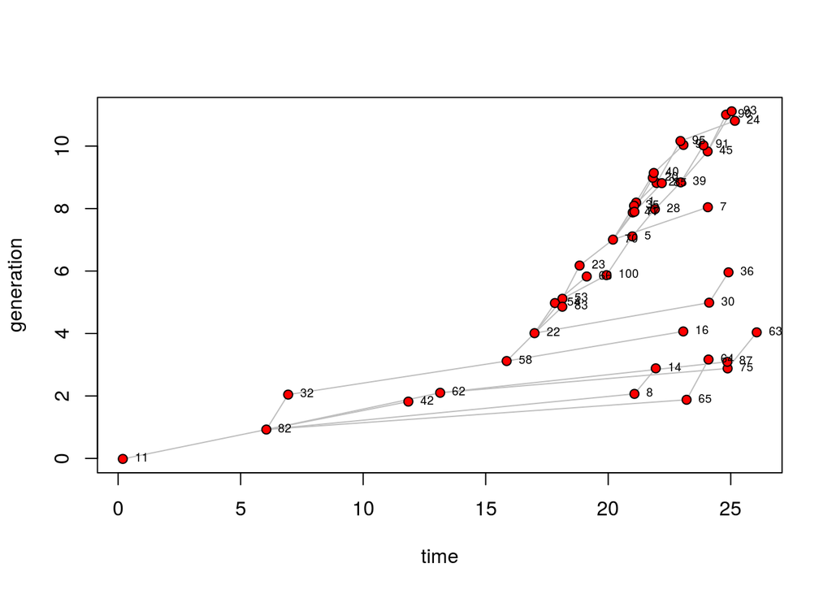

This view of course has its own drawbacks. Depending on the network structure, it is possible for many of the vertices and edges in the tree to overlap.

Data for constructing tPaths for real world transmission processes may be availible in public health contexts. For example containing serious infectious disease, contact tracing interviews are often employed to track back from the set of known infected individuals to the possible infection source to locate additional exposed persons and determine some of the disease spreading properties (i.e. “Basic reproduction number”) even when the overall population contact network cannot be reconstructed.

For example, we can consider epidemic data derived from a measles outbreak in the town of Hagelloch, Germany in 1861. 188 individuals were infected over the course of the epidemic. The underlying contact network is not observed, although it could be somewhat infered via household and classroom membership and proximity.

```
##
## epinet: version 2.1.6, created on 2015-11-14
```

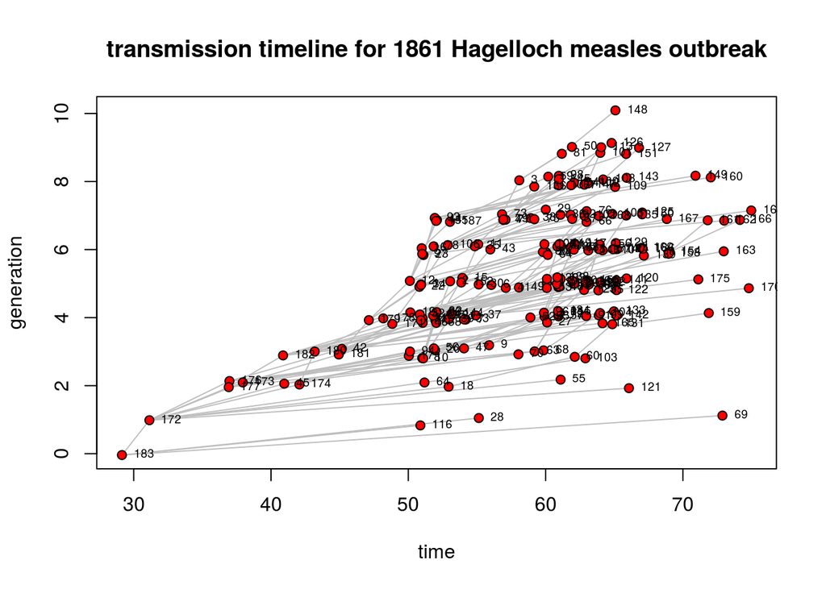

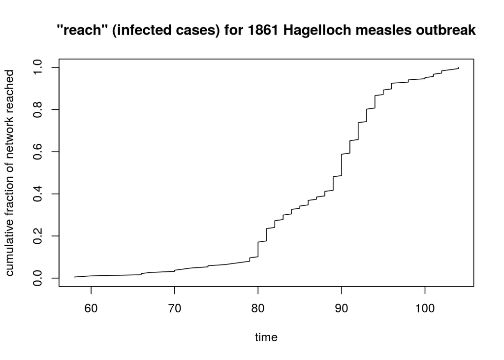

## Computing properties of the network using earliest forward path

The shortest path geodesic distance measure serves as the basis of a large number of network measures (cite Brandes). It seems useful to generalize some of the measures to temporal networks using the earliest forward path. (cite moody)

### Dynamic reachablity and connectedness

Several authors have proposed a ‘reachability graph’ projections of dynamic networks. This graph would be a representation of a dynamic network having the same vertices, but the original edges are replaced by directed arcs between vertices whenever it is possible to make a journey from one to the other. The earliest forward path provides an relatively efficient way to construct it.

Easy to compute the earliest forward set from any vertex. Compute a directed reachability matrix for any starting time. partition using directed component measures.

If the network has been observed long enough to be fully reachable, we will need to apply a threshold to the temporal distances reachability matrix in order to effectively break up the network

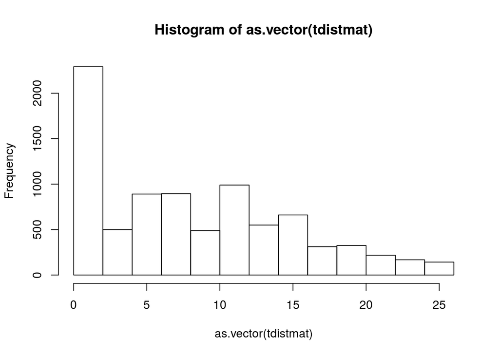

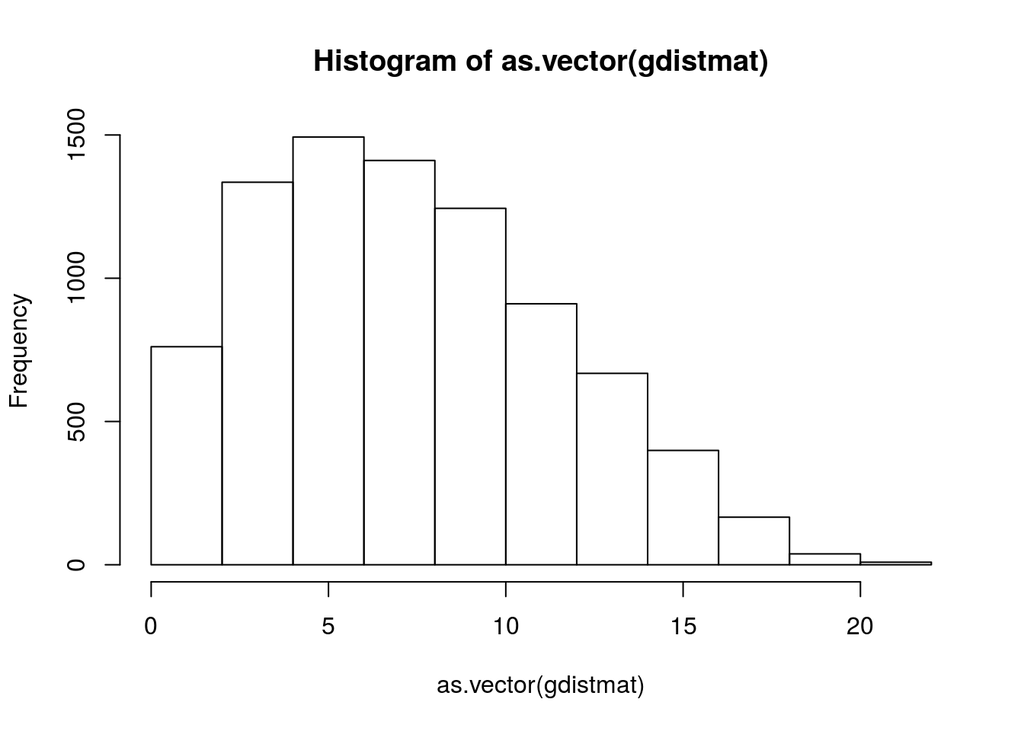

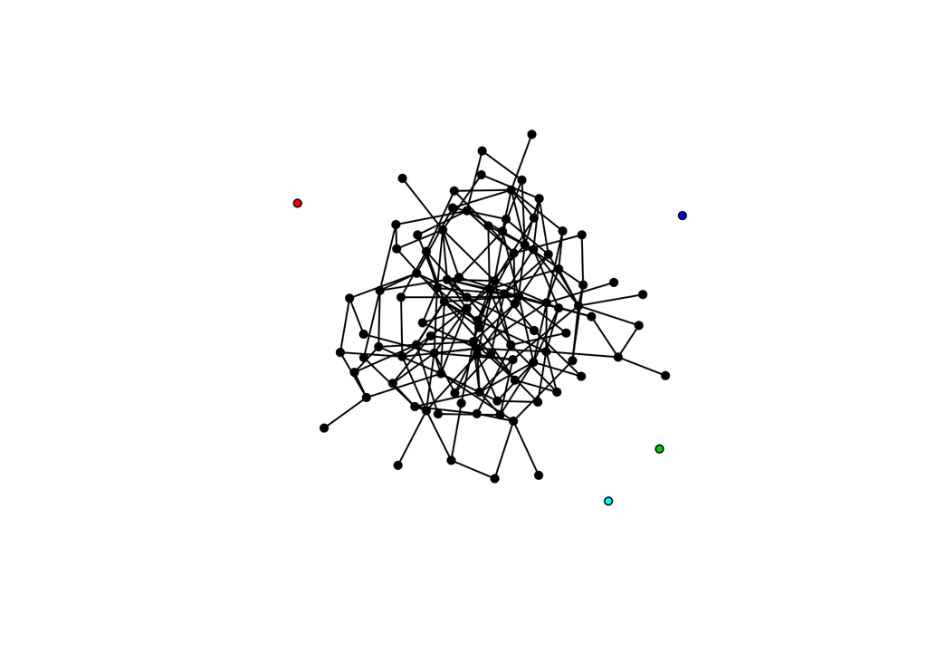

Compare the distribution of path lengths from aggregate, a single cross section, and earliest fwd paths

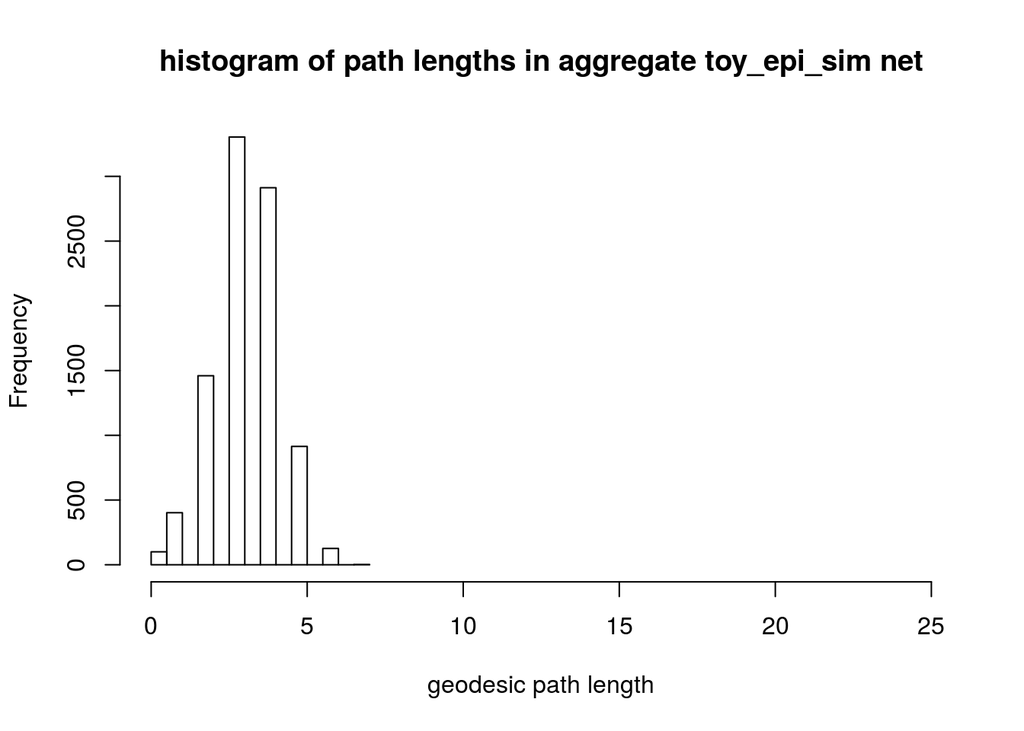

```r
hist(as.vector(geodist(as.matrix(toy_epi_sim))$gdist),
     main='histogram of path lengths in aggregate toy_epi_sim net',
     xlab='geodesic path length',xlim=c(0,25))
```

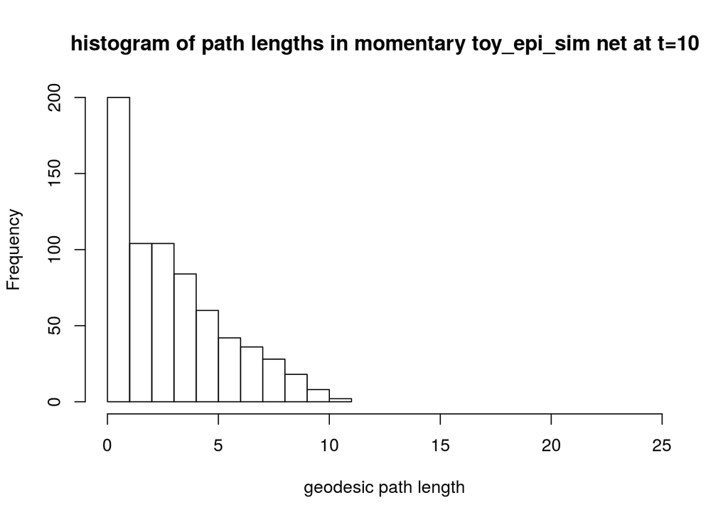

```r
hist(as.vector(geodist(as.matrix(network.extract(toy_epi_sim,at=10)))$gdist),
     main='histogram of path lengths in momentary toy_epi_sim net at t=10',
     xlab='geodesic path length',xlim=c(0,25))
```

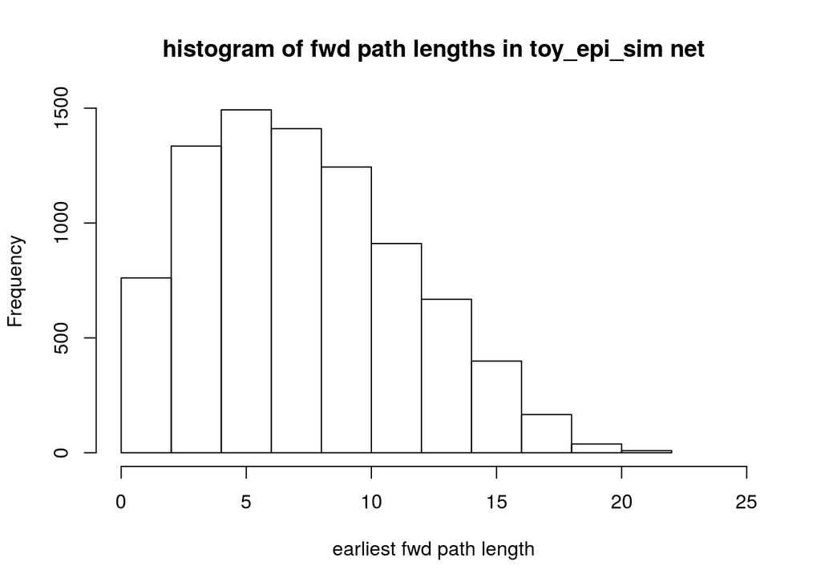

```r
hist(as.vector(gdistmat),
     main='histogram of fwd path lengths in toy_epi_sim net',
     xlab='earliest fwd path length',xlim=c(0,25))
```

### dynamic centrality measures

We can calculate an temporal extension of a betweeness measure using the earliest forward paths rather than the geodesics on static graphs (Cite Moody) Cite Brandes (2008). This computes the number of shortest earliest forward paths that each vertex lies on. The standard definition of betweeness would then divide this by the number of shortest paths between each vertex pair in order to weight the shortest paths by the inverse of their redundency (Cite Butts sna)

Since it is possible to define a betweeness score for vertices, it seems likely that it could be similarly defined for edges, which would lead to the possibility of temporal edge-betweenness clustering where the ‘transmiting’ spells of the highet betweeness edges are sequentially deleted and the scores are recalulated until the graph is partitioned. ’tho I’m not sure there is an immediate extension to a temporal modularity score.

possible to infer network properties using methods analagous to link tracing or Respondent Drivin Sampling design?

CONTRAST SOONNESS centrality, tReach, and tiedDuration with simulated epidemic sizes

## Observation window and network rate scaling issues

### Temporal boundry problem

Defining the temporal bounds of the observed network evolution raise some significant issues. For many classes of networks – certainly most stochastic network models – if the simulation is run long enough the network will become fully temporally reachable. Eventually enough ties will have formed and disolved so that there is a temporally permissable path from every vertex to every other. So how can we determine the correct time window for measuring a network process? Somewhat similar to the “network boundry problem”" in determining the appropriate vertex set for a network. For real-world data, the temporal boundries are usually somewhat arbitrary, defined by the limits of an archive or resource constraints of data collection.

if a tie toggles on and off a lot very quickly, from the perspective of a transmission process its temporal connectivity approaches that of a ‘weak’ tie that is always active.

network growth process, impact of vertex vital dynamics

### Time unit problem

It seems that there should be a measure that allows us to compare ‘how good at spreading’ different networks are. Standard measure of network density is impacted by network size. Larger networks have lower density because the number of potential dyads is greater, even if the amount of connectivity expeireced by individual vertices are similar. A ‘size invarient’ representation of density to express the number of ties from the perspective of individual vertices and make comparsions of different sized networks using mean degree of vertices instead of density. This suggests similar transformation for rates, expressing rate of change as an expected mean time until an edge toggle. Possible to calculate this from sampled egocentric data even when the network for a full population cannot be collected?

## Measures of transmission potential

Ideally the values for the metrics shouldn’t depend on how long we observe the network. Having a longer observation period should reduce the error in measurement, not change the values of coefficients we get back.

Crude measure is simply churn, how many edges are formed and broken. But a network could have a very high churn rate by forming and breaking the same edges without achieving any new connectivity. Seems like for this what we want to find is the rate at which paths are able to discover new vertices.

How quickly is the network mixing? many possible ways to quantify the mixing: * How long does it take to reach X fraction of the network? Problem. The network may not be reachable within the observed time period. * Fracition of sampled t paths that reach the maximum size within a given time period * Mean rate at which ‘new’ vertices are reached by forward paths.

As long as we are thinking about these as processes where infect.prob=1.0, we can efficiently calculate them with earliest forward path.

“mean size of infected component at t=100” or “mean time to reach 50% of vertices” are hard to compare across networks if time units don’t match. Or, even if units are comparable, the observation period for one network may be too short.

impacts of tie duration? vs length of observation window. li’s work http://students.washington.edu/lxwang/summary%20plots.2.html

### Path saturation, finite population size effects

Assuming that the network is not a growth process (with new verticies being added over time) and is fairly homogenous in rates the size of a network works to bound the maximal growth of the forward components following the logistic curves that describe epidemic growth. As the number of vertices reached grows over time, the “front” of vertices able contact unreached vertices increases, but after a significant fraction of the population has be reached, it becomes increasingly unlikely that the few remaining vertices will happen to be found.

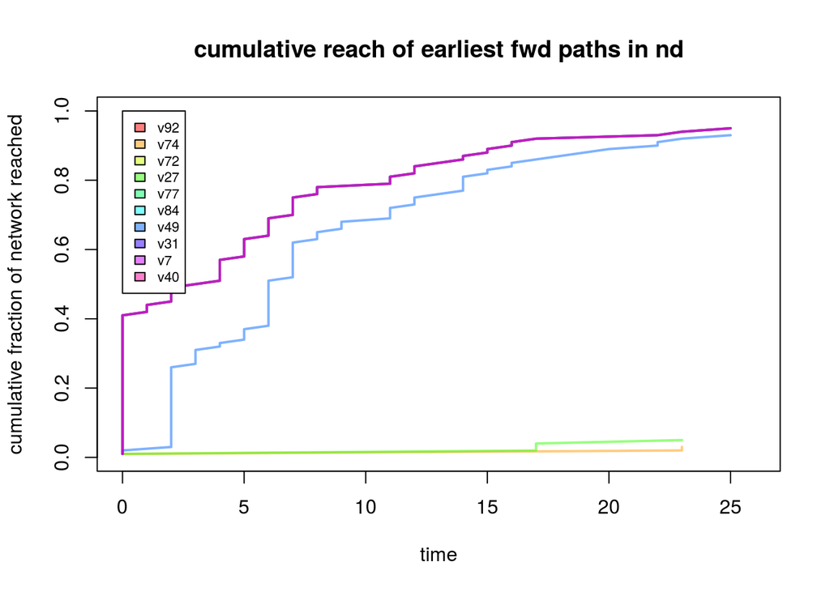

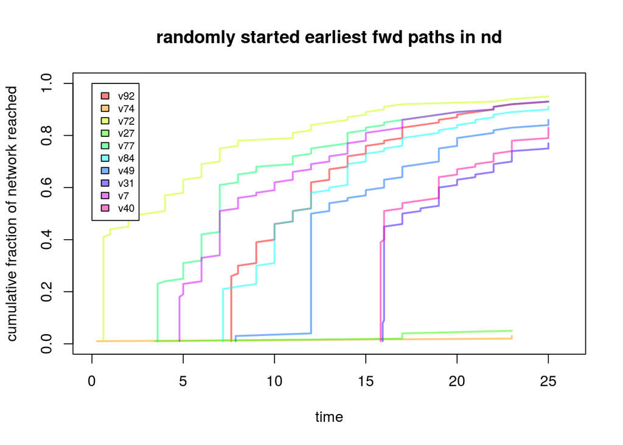

The saturation effect means that if we want a discriptive statistic for the transmission potential of a network over time, we may not want to start all of the seeds for the forward paths at the beginning of the observation period. To characterise the overall observed network accurately we likely need to choose random starting times in addition to random seeds and calculate the rate based on the amount of time each path was given to spread.

Alternate possiblity: “wrap-around” infections – when the end of the time window is reached, start searching again from time 0, from all of the vertices reached so far. Problem then is stopping criteria.

### Reachable rate

The *mean reachable rate* for a network, we select a number of seed vertices at random, and for each seed select a random starting time within the network’s observation period. For each seed, compute the size of the forward reachable set (starting from the associated time) and divide by the duration of time remaining for the seed to spread. Closely related to the “reproduction number” or “R naught” in epidemiology or population ecology.

Comparing values for toy_epi_sim computed starting all paths from zero with starting at random times. The random start gives larger values because the “slow tail” part of the path is trimmed off for more networks. This value is not necessairly “more accurate” (it may be an over-estiamte) but it should be less suceptible to window effects of observation duration.

```r
rRate(toy_epi_sim,sample.size=100,start=0,end=26,random.times = TRUE)
```

```
## [1] 5.124311
```

```r
rRate(toy_epi_sim,sample.size=100,start=0,end=26,random.times = FALSE)
```

```
## [1] 3.349231
```

Aside: Interesting question about sample validity. Seeds are chosen at random but unless the population size is very large, it is likely that the forward reachable components found from each seed are not independent. If there is a region of the graph that is strongly temporally connected, it is likely that many of the seeds will discover nearly the same set of reachable vertices. Does this mean that large FRS are likely to over-represented in samples on graphs that have them?

### Mean reach per toggle

in the amount of time it takes on average for the network to toggle one edge on or off, how many new vertices can be reached on average?

The mean reachable rate provides an index of the relative rate of potential spread vs the time units of the network itself. So it may be suitable for comparing networks using the same time-units. However, it is not a unit-free “rate invariant measure”. It cannot distinguish between when diferences in the values are caused by topological differences in network connectivity or simply that one network evolves at a faster rate (or is measured in larger time units) than another. The *mean reach per toggle* divides the mean reachable rate compute the average amount of time (per capita) until a the next edge toggle in the network. Mean reach per toggle is a measure of how often new ties form with new vertices vs already reached vertices. A value of 0 would mean that edges only toggle on and off between the same vertex pairs, but no new mixing occurs. A value of 1 would mean that every toggle reaches a new vertex, and values > 1 would mean that every toggle connects to a set of previously unreachable vertices.

## Comparing metrics on some example networks

The table below provides some very basic statistics for comparison among several simulated and observed networks.

| net.names | reachable.rate | net.size | net.dur | mean.edge.dur | time.to.toggle | reach.per.toggle |
| --- | --- | --- | --- | --- | --- | --- |
| base.sim | 5.9740470 | 1000 | 100 | 20.159115 | 3.245699e+01 | 0.1840604 |
| middle.sim | 1.6833911 | 1000 | 100 | 19.411888 | 3.221649e+01 | 0.0522525 |
| monog.sim | 1.3954240 | 1000 | 100 | 19.974278 | 3.267974e+01 | 0.0427000 |
| short.stergm.sim | 0.6741767 | 16 | 25 | 10.531250 | 4.255319e+00 | 0.1584315 |
| toy.epi.sim | 6.4670638 | 100 | 25 | 6.861538 | 8.361204e+00 | 0.7734608 |
| hospital.rfid.contact | 0.0003291 | 75 | 347520 | 569.341528 | 9.284035e+02 | 0.0000004 |
| manufacturing.co.emails | 0.0000205 | 167 | 23426882 | 14.283022 | 2.367841e+04 | 0.0000000 |
| enron.emails | 0.0000076 | 184 | 141075619 | 12.201920 | 2.744254e+05 | 0.0000000 |

### Concurrency Comparison networks

Example plots of momentary networks and Cumulative time to reach plots

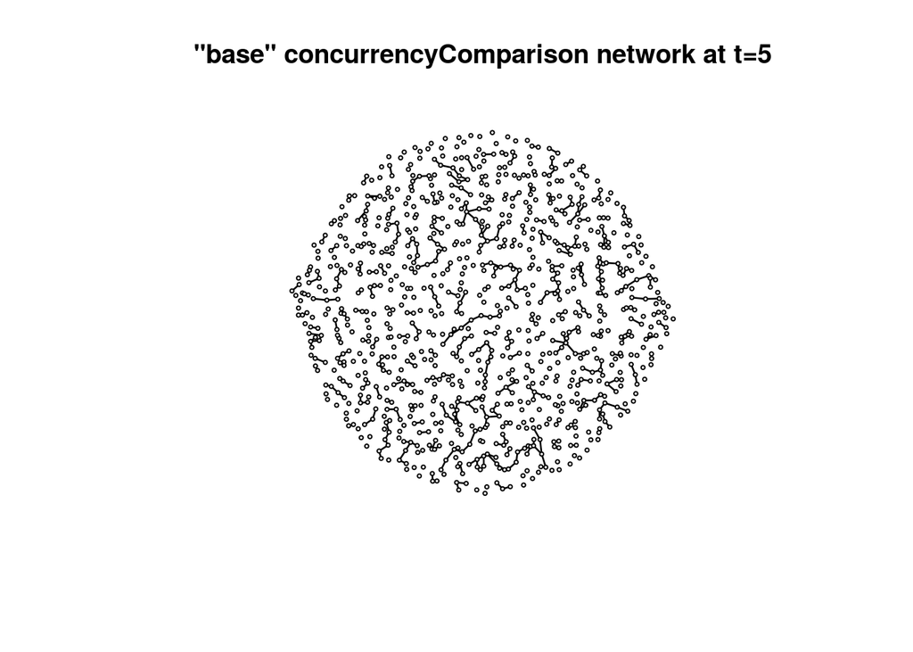

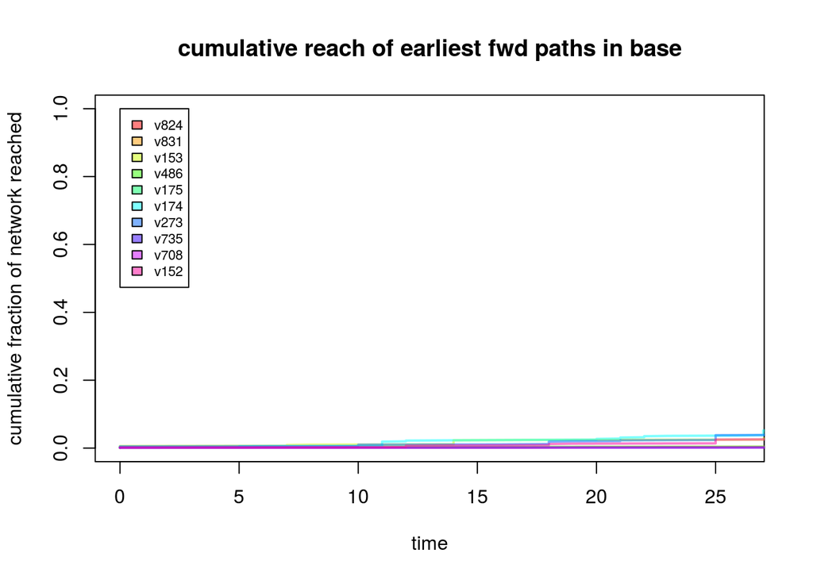

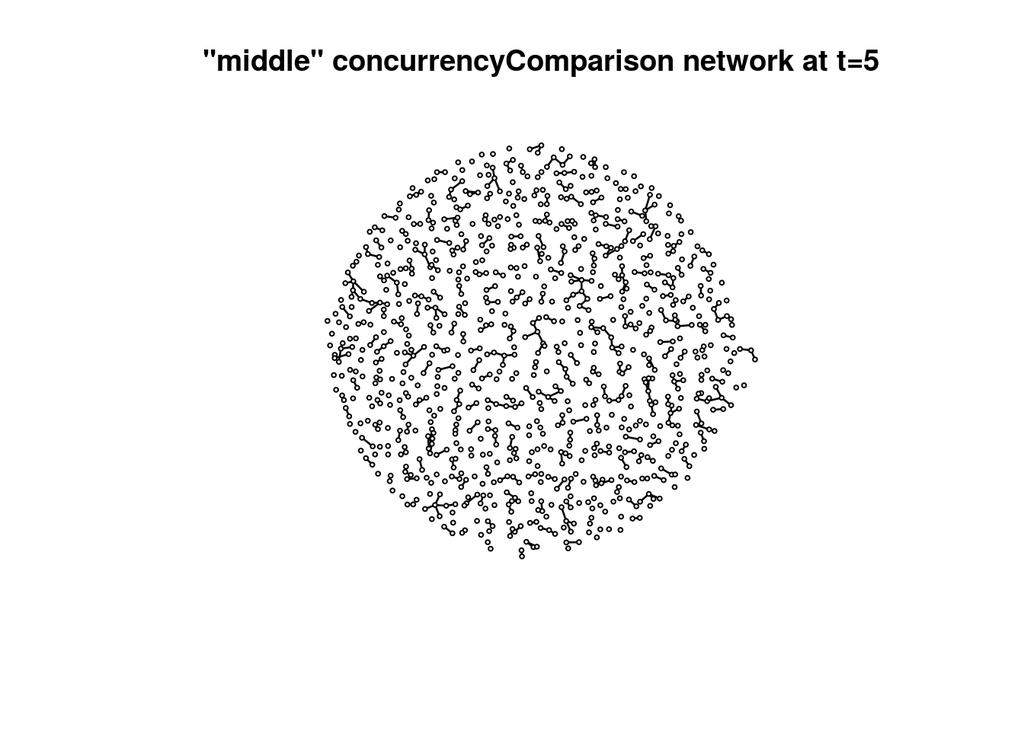

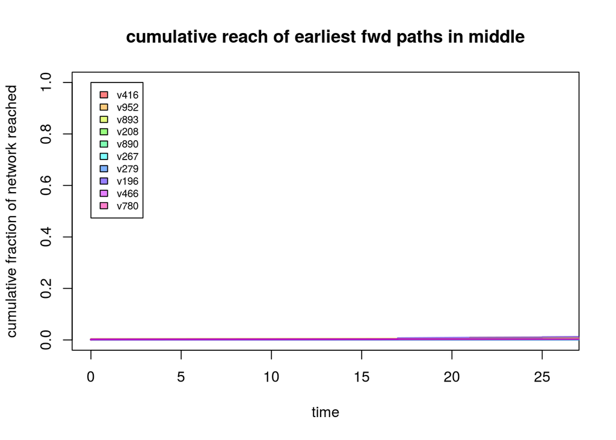

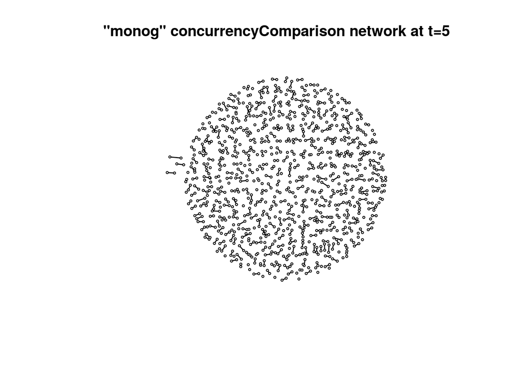

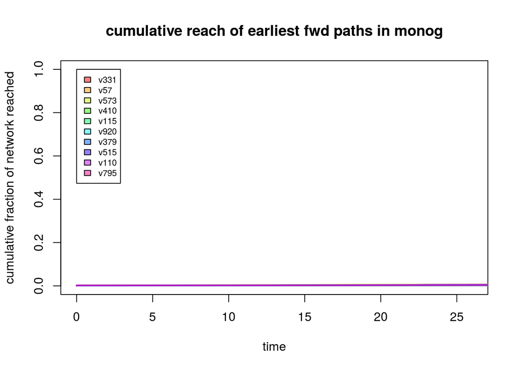

### Other tergm sims

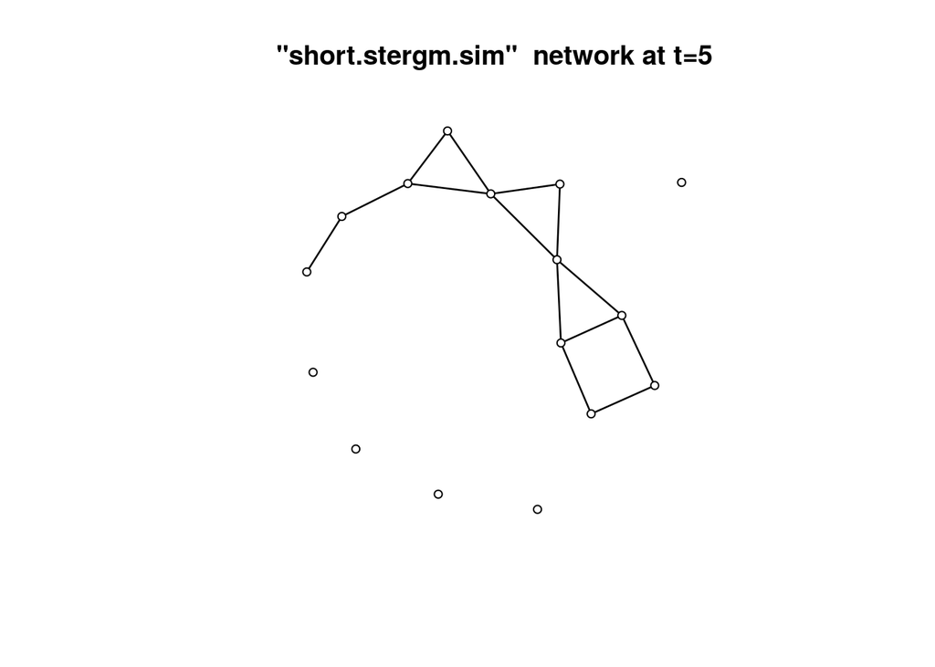

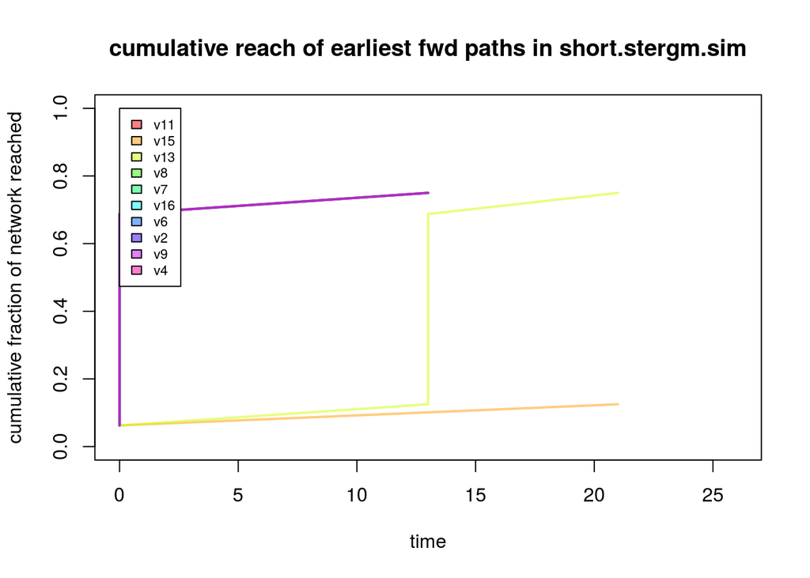

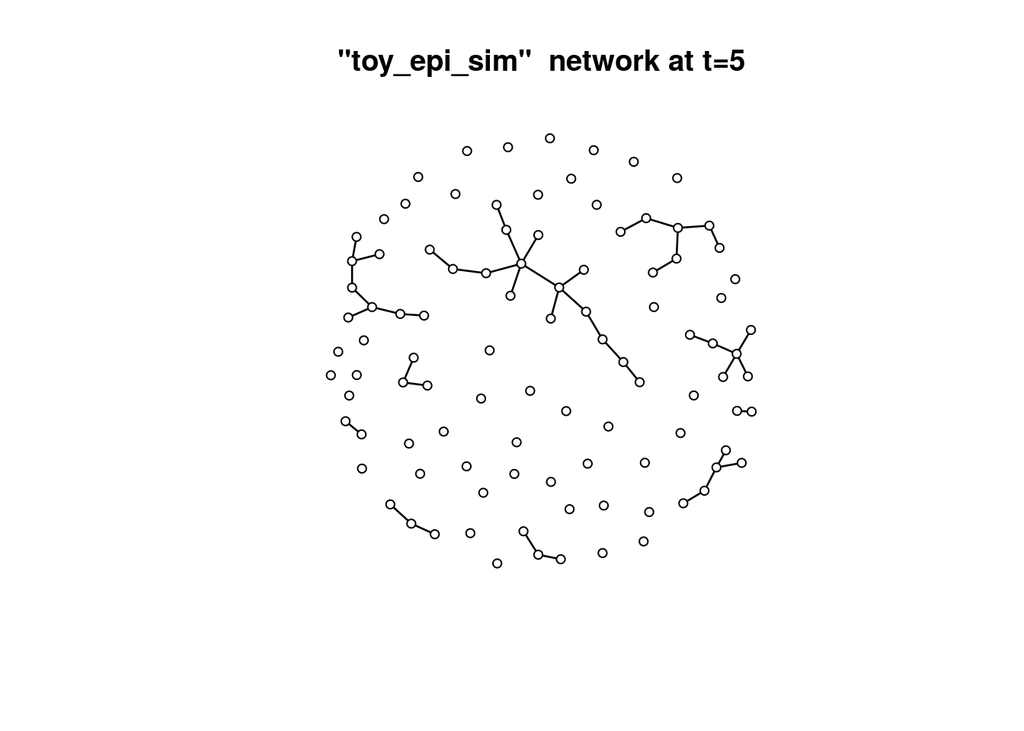

### hospital contact rfid example

real networks often have periodicity, at multiple time scales

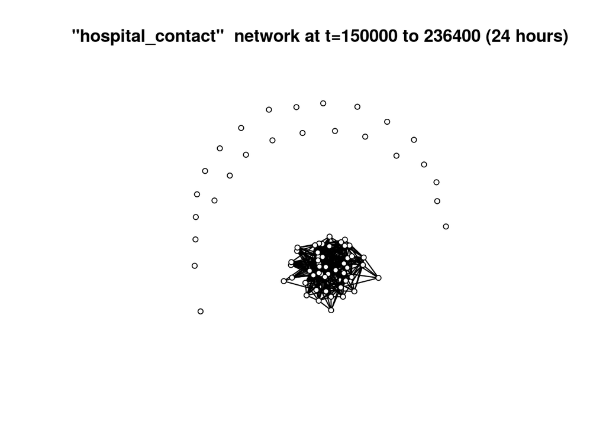

[figure not shown]

### email network examples

Enron, Polish manufacturing continusous time

### transportation network

BART (a network designed to transmit efficiently)

## Relationship to SI models of infection processes

Epidemilogical infection models of real disease are necissairly complicated in order to account for lots of crucial details of disease process, changes in viralance over the duration of infection, mortality, recovery etc. Exact values for many crucial parameters (HIV infectivity) are not known and are difficult to research ethically. How far can we get just be understanding the maximal infection sizes permitted by the underlying contact network?

Earliest fwd path provides hard upper bound on infection reach, transmission tree *is not* necessiairly the substrate that SI model spreads across. Many networks will include alternate paths (including shortest and most likely) which are not the earliest forward path. How often is this the case for networks that we care about (‘realistic’ disease transmission networks) (are the paths in these networks constrained enough that earliest path gives an easy to calculate huristic)?

Earliest fwd path algortihm can be considered an SI process with infect. prob = 1.0, it not obviously well suited to modeling other infection rates as its efficiency is partially gained by its ability to avoid ‘visiting’ any timesteps intermediate to changes in the network tie structure – these steps would generally be needed to evaluate probabalistic computations of infection status.

One could assume that for many networks, a lower tdist would correspond to an increased likelyhood of a vertex being reached in an infection process. Or more precisely, a large tdist means that we know a vertex is not reachable until late in the network’s evolution, so even if the infection does not travel on the earliest fwd path, there is much less time remaining for vertex to be reached by alternate routes.

measuring the size of an epidemic, generation time, fraction reached at t, vs time to reach a fraction

### Comparison with transmission simulations (EpiModel)

For discrete time network models, we can use discrete time epidemiologial transmission simulations as an alternate means to compute the forward reachable set. For this paper, we adapted Samuel Jenness (2015) modules for simulating epidemics on observed networks using the EpiModel package (Jenness, et al 2015) to compute SI infection trees as tPaths while permitting us to vary the infection propability rates and run batches of simulations from multiple seeds in a single network realization.

When comparing the earliest path results with a discrete time infection model, it is important to be explicit about the assumptions of the duration required for a transmission to occur (or be observed). By default, the path calculations in `tsna` and in analytical approaches to computing reachable sets usually assume transmission can occur instantly across edges that are active at the same time. A discrete time epidemic model usually requires that propagation can only occur one edge per time unit – initial infection and re-transmission cannot occur in the same timestep. This distinction is crucial when a forward reachable path encounters an existing component or densly connected region in the network. If the graph.step.time parameter is assumed to be zero, the entire component can be reached in a single instant, greatly accelerating the path’s reach. This may be quite appropriate if the phenomena being modeled is one where the rate of transmission is dramatically faster than the rate of network change (electricity distribution networks for example) but will mean that discovery times and reachable set may not match up with an epi-style transmission sim.

The boundry conditions are also important, they need to stop at the same timestep to give the same results.

### population risk (size and likelyhood of an epidemic)

How useful is the distribution of forward component sizes at predicting the distribution of epidemic sizes? There are potentially many ways to measure risk to a population from randomly seeded infections. Do we compare the sizes of the worst-case-scenario (maximum possible infection size)? An average of a sample of infections sizes? For now, we will compare the shapes of distributions of infection sizes in the three “concurrency comparison networks”.

First we consider the ‘base’ network and compare the sampled distributions of infected component sizes for the four infectivity levels.

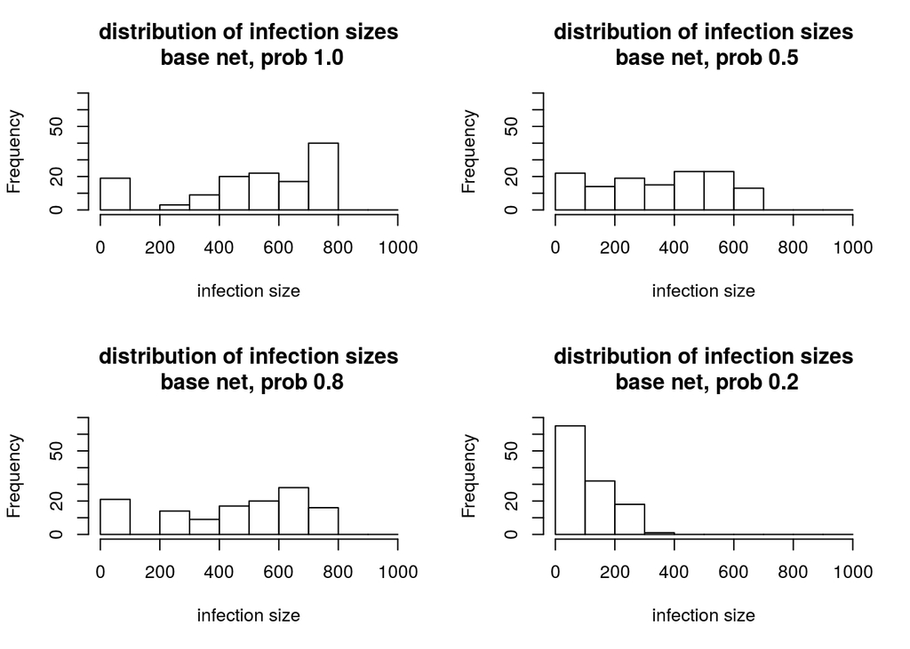

It appears that lowering the infectivity of the transmission process shifts the distribution of epidemic sizes more and more towards shorter, smaller epidemics when compared to the earliest fwd set sizes. Presumeably this is because completing the number of graph hops needed to create the larger infections become less and less likely as the infection probability is lowerd and the effects of network strucutre are diminished. Less likely to make it far enough to actually hit one of the bottlenecks that that opens up a big new region of the network.

We see similar trends for the two other networks with differing momentary degree distributions – allthough the ‘monog’ network the epidemic sizes are quite small to begin with

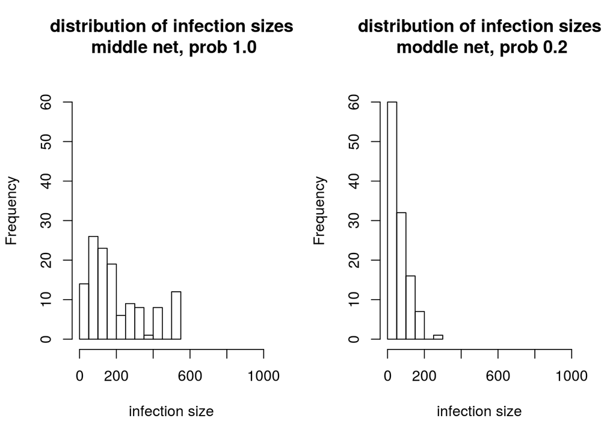

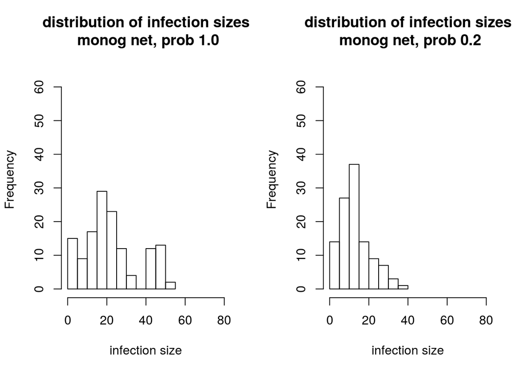